# Common errors and how to fix them

Day 1 - Introduction to Data Analysis with R

Selina Baldauf

Freie Universität Berlin - Theoretical Ecology

October 17, 2026

## Errors are how you learn

When learning a programming language, you will run into errors all the time. That’s completely normal and it’s how programming works!

## First things first: Set R to English

- The R language setting follows your operating system language by default
- Errors might not be in English - hard to find help online

#### Fix: Change the R language setting to English

```r
# For the current session
Sys.setLanguage("en")
```

**Add it to your .Renviron**

The `.Renviron` file is read automatically every time you start R.

Open the file with:

```r
# install the usethis package
# install.packages("usethis")
# Open the .Renviron file in RStudio
usethis::edit_r_environ()
```

and add the line `LANGUAGE=en` to the file. Save it and restart R.

# Most common errors for beginners

> and how to deal with them

## Console prints `+`

R is not running code anymore and the console only prints `+`

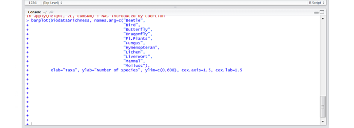

#### How to fix it

- Go to the console and hit `Escape`. Then you should see the `>` sign instead of `+` again.
- Likely you forgot to close a bracket or a quote somewhere. Go to your script and check where this happened (look for next to line numbers)

## Syntax errors

#### Example

```r
mean(c(1, 2, 3)na.rm = TRUE)
```

```
#> Error in parse(text = input): <text>:1:16: unexpected symbol
#> 1: mean(c(1, 2, 3)na.rm
#>                    ^
```

#### How to fix

- Look for missing commas, misspelled arguments, unclosed brackets, …
- Read the error message, it often points you to where the problem is
- The RStudio syntax checker warns you **before** you run code with syntax errors
  - Look for next to line numbers in your script

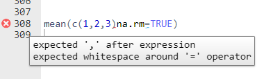

## Error: object not found

#### Example

```r
variable_A
```

```
#> Error:
#> ! object 'variable_A' not found
```

#### How to fix

- You are trying to access an object that does not exist. Common reasons:
  - Typo in the variable name (e.g. you created `variableA` but typed `variable_A`)
  - You forgot to run the line of code that creates the variable
  - You forgot to put quotes around a string: `print(hello)` looks for a **variable** named `hello`, but you wanted `print("hello")`

## Package problems

#### Could not find function

```r
read_csv("data/penguins.csv")
```

```
#> Error in `read_csv()`:
#> ! could not find function "read_csv"
```

- You forgot to **load the package**: `library(tidyverse)`
- You have a **typo** in the function name (e.g. `lenght()` instead of `length()`)

#### Package not found

```r
library(thispackagedoesntexist)
```

```
#> Error in `library()`:
#> ! there is no package called 'thispackagedoesntexist'
```

- The package is **not installed**: `install.packages("thispackagedoesntexist")`
- You have a **typo** in the package name

Remember for packages: **install once**, but **load every time** you start R

## File not found

When reading data, you might see errors like:

```r
readr::read_csv("data/penguins.csv")
```

```
#> Error:
#> ! 'data/penguins.csv' does not exist in current working directory:
#>   'C:/Users/Selina/Documents/Repos/Teaching/intro-r-data-analysis/sessions/slides'.
```

#### How to fix

- Check that you are in the **correct RStudio project** (look at the top right corner of RStudio)
- Check the **file name**: is it spelled exactly right?
- Check the **folder path**: is the file actually in the `data/` folder?

**Build your path with auto-completion**

When you start typing a path in RStudio, you can use auto-completion to avoid typos. Start with `""` and then hit tab to see suggestions for files and folders in your project.

## Not all red text is an error

- **Errors**: something went wrong and your code did not run
- **Warnings**: your code still ran, but R tells you something might be wrong (e.g. `NA` values in your data)
  - Make sure to **read and understand** warnings
  - Only ignore them if you know that’s okay
- **Messages**: just information, e.g. when you load the tidyverse

## What to do when you’re stuck

- Read the error message
- Check your data: use summary() or View() to see if your data looks the way you expect
- Read the function help with ?function_name
- Restart R and run your script from the top (Session > Restart R in RStudio)
- Search online or ask AI

Make sure to **save your scripts regularly**. Sometimes R crashes and you have to start a new R session.